# R Notebook

# Customer Segmentation Group work

## Instructions

- Imagine you and your team mates have just founded a Data Science start up. Your first customer is a fundraising organization asking for support with regard to making most of their donor and transaction data.
- The Head of Fund Development who is your direct counterpart and project sponsor asks your team to come up with a segmentation of the donor base as quickly as possible. The manager has a basic understanding of RFM modelling and tells you that there was a simple model in use some years ago which was neither updated nor further developed.
- In general, your client organization is model-agnostic and trusts your judgment and consulting. However, the let you know that seeing alternative approaches in action together with your reflection, expertise and concluding recommendation how to process would be great …
- The clients finally provide you with a flat file together with a list of feature descriptions …

### Tasks

- Form a group of 3 to 4 persons
- Get accustomed to the data and have an explorative look at it.
- Think your variables that might be added to or derived from the dataset with relative ease, e.g. conducting some research, data enrichment etc.
- Take those down and formulate recommendations towards the client.
- If you find time and a viable data source, you may of course go ahead and enrich the dataset
- Apply at least two customer segmentation approaches to the provided data
- Model examples: RFM, k-Means-Algorithm
- Summarize the segmentation generated results and derived insights
- Compare the model outputs and formulate a recommendation for the customer

### Expected Output

- Deliverable: Pitch presentation
- Deadline: December 17th, 2021

## Prepro

```r
library(tidyverse, readr)
feature_description_original <- readxl::read_excel(
  "data/feature_description.xlsx")
feature_description_original
```

| Customer Number | Unique Identifier of Donor |
| --- | --- |
| Gender | Gender of person |
| Date of Birth | Customer´s date of birth (dd.mm.yyyy) |
| Postcode | Postal code (Austria) |
| COUNT2015 | Sporadic Donation Frequency 2015 |
| SUM2015 | Sporadic Donation Sum 2015 |
| MERCHANDISE2015 | Has customer made at least one purchase in merchandising store in 2015? |
| COUNT2016 | Sporadic Donation Frequency 2016 |
| SUM2016 | Sporadic Donation Sum 2016 |
| MERCHANDISE2016 | Has customer made at least one purchase in merchandising store in 2016? |
| COUNT2017 | Sporadic Donation Frequency 2017 |

[output cut: 10 more lines]

```r
customer_segmentation_raw <- readr::read_csv2(
  "data/customer_segmentation_test.csv",
  col_types = list(col_integer(), col_character(), col_character(), col_character(),
                col_double(), col_double(), col_character(), col_double(), col_double(),
                col_character(), col_double(), col_double(), col_character(), col_double(),
                col_double(), col_character(), col_double(), col_double(), col_character(),
                col_character(), col_character()),
  guess_max = 400000
)
```

```
## i Using "','" as decimal and "'.'" as grouping mark. Use `read_delim()` for more control.
```

```r
customer_segmentation_raw <- customer_segmentation_raw %>% mutate(
  `Date of Birth` = lubridate::dmy(`Date of Birth`),
  Gender = as.factor(Gender),
  MERCHANDISE2015 = as.factor(MERCHANDISE2015),
  MERCHANDISE2016 = as.factor(MERCHANDISE2016),
  MERCHANDISE2017 = as.factor(MERCHANDIESE2017),
  MERCHANDISE2018 = as.factor(MERCHANDIESE2018),
  MERCHANDISE2019 = as.factor(MERCHANDISE2019),
  LastPaymentDate = lubridate::dmy(LastPaymentDate),
  PenultimatePaymentDate = lubridate::dmy(PenultimatePaymentDate)
) %>% select(-c(MERCHANDIESE2017, MERCHANDIESE2018)) %>%
  rename(DateOfBirth = `Date of Birth`,
         ID =`Customer Number`)

skimr::skim(customer_segmentation_raw)
```

Data summary

| Name | customer_segmentation_raw |
| --- | --- |
| Number of rows | 406734 |
| Number of columns | 21 |
| _______________________ |  |
| Column type frequency: |  |
| character | 1 |
| Date | 3 |
| factor | 6 |
| numeric | 11 |
| ________________________ |  |
| Group variables | None |

**Variable type: character**

| skim_variable | n_missing | complete_rate | min | max | empty | n_unique | whitespace |
| --- | --- | --- | --- | --- | --- | --- | --- |
| Postcode | 9176 | 0.98 | 1 | 9 | 0 | 2982 | 0 |

**Variable type: Date**

| skim_variable | n_missing | complete_rate | min | max | median | n_unique |
| --- | --- | --- | --- | --- | --- | --- |
| DateOfBirth | 155491 | 0.62 | 1902-04-21 | 2015-03-30 | 1948-03-09 | 25514 |
| LastPaymentDate | 0 | 1.00 | 2015-01-03 | 2020-02-13 | 2018-12-06 | 1361 |
| PenultimatePaymentDate | 44699 | 0.89 | 1995-12-31 | 2020-02-05 | 2017-04-12 | 5376 |

**Variable type: factor**

| skim_variable | n_missing | complete_rate | ordered | n_unique | top_counts |
| --- | --- | --- | --- | --- | --- |
| Gender | 0 | 1 | FALSE | 3 | fem: 203904, mal: 183467, fam: 19363 |
| MERCHANDISE2015 | 0 | 1 | FALSE | 2 | 0: 401845, 1: 4889 |
| MERCHANDISE2016 | 0 | 1 | FALSE | 2 | 0: 401585, 1: 5149 |
| MERCHANDISE2019 | 0 | 1 | FALSE | 2 | 0: 401470, 1: 5264 |
| MERCHANDISE2017 | 0 | 1 | FALSE | 2 | 0: 402378, 1: 4356 |
| MERCHANDISE2018 | 0 | 1 | FALSE | 2 | 0: 401470, 1: 5264 |

**Variable type: numeric**

| skim_variable | n_missing | complete_rate | mean | sd | p0 | p25 | p50 | p75 | p100 | hist |
| --- | --- | --- | --- | --- | --- | --- | --- | --- | --- | --- |
| ID | 0 | 1 | 203367.50 | 117414.14 | 1 | 101684.2 | 203367.5 | 305050.8 | 406734.0 | ▇▇▇▇▇ |
| COUNT2015 | 0 | 1 | 2.52 | 4.00 | 0 | 0.0 | 2.0 | 2.0 | 96.0 | ▇▁▁▁▁ |
| SUM2015 | 0 | 1 | 42.44 | 850.19 | 0 | 0.0 | 15.0 | 45.0 | 388113.6 | ▇▁▁▁▁ |
| COUNT2016 | 0 | 1 | 1.22 | 2.02 | 0 | 0.0 | 1.0 | 1.0 | 178.0 | ▇▁▁▁▁ |
| SUM2016 | 0 | 1 | 50.93 | 591.05 | 0 | 0.0 | 16.0 | 50.0 | 295599.8 | ▇▁▁▁▁ |
| COUNT2017 | 0 | 1 | 1.06 | 1.91 | 0 | 0.0 | 0.0 | 1.0 | 95.0 | ▇▁▁▁▁ |
| SUM2017 | 0 | 1 | 24.78 | 572.90 | 0 | 0.0 | 0.0 | 20.0 | 207134.7 | ▇▁▁▁▁ |
| COUNT2018 | 0 | 1 | 1.00 | 1.87 | 0 | 0.0 | 0.0 | 1.0 | 49.0 | ▇▁▁▁▁ |
| SUM2018 | 0 | 1 | 20.64 | 1552.60 | 0 | 0.0 | 0.0 | 15.0 | 911146.5 | ▇▁▁▁▁ |
| COUNT2019 | 0 | 1 | 0.97 | 1.79 | 0 | 0.0 | 0.0 | 1.0 | 31.0 | ▇▁▁▁▁ |
| SUM2019 | 0 | 1 | 46.44 | 3999.80 | 0 | 0.0 | 0.0 | 30.0 | 2400000.0 | ▇▁▁▁▁ |

### feature engineering

Bin hier sehr offen für Verbesserungsvorschläge ^^

```r
zip_code_list <- readxl::read_excel("data/PLZ_Verzeichnis-20211201.xls")
zip_code_list
```

| PLZ | Ort | Bundesland | gültig ab | gültig bis | NamePLZTyp | intern_extern | adressierbar | Postfach |
| --- | --- | --- | --- | --- | --- | --- | --- | --- |
| 1000 | Wien | W | 01.08.2009 | NA | PLZ-Postfach | extern | Nein | Ja |
| 1004 | Wien | W | 01.01.1966 | NA | InteressentenPLZ | extern | Nein | Ja |
| 1006 | Wien | W | 01.02.2015 | NA | PLZ-Postfach | extern | Nein | Ja |
| 1010 | Wien | W | 01.01.1966 | NA | PLZ-Adressierung | extern | Ja | Ja |
| 1011 | Wien Postfach | W | 01.01.1966 | NA | PLZ-Postfach | extern | Nein | Ja |
| 1015 | Wien | W | 01.01.1966 | NA | PLZ-Postfach | extern | Nein | Ja |
| 1016 | Wien | W | 01.01.1966 | NA | PLZ-Postfach | extern | Nein | Ja |
| 1017 | Wien-Parlament | W | 22.04.2015 | NA | InteressentenPLZ | extern | Nein | Ja |
| 1020 | Wien | W | 01.01.1966 | NA | PLZ-Adressierung | extern | Ja | Ja |
| 1021 | Wien Postfach | W | 01.01.1966 | NA | PLZ-Postfach | extern | Nein | Ja |

[output cut: 990 more lines]

```r
customer_segmentation_with_zip <- customer_segmentation_raw %>%
  left_join(zip_code_list, by = c("Postcode" = "PLZ")) %>%
  select(-c(`gültig ab`, `gültig bis`, NamePLZTyp, intern_extern, adressierbar, Postfach)) %>%
  drop_na(Postcode, Ort, Bundesland) %>%
  mutate(Postcode = as.factor(Postcode),
         Bundesland = as.factor(Bundesland))

customer_segmentation_with_zip
```

| ID | Gender | DateOfBirth | Postcode | COUNT2015 | SUM2015 | MERCHANDISE2015 | COUNT2016 | SUM2016 | MERCHANDISE2016 | COUNT2017 | SUM2017 | COUNT2018 | SUM2018 | COUNT2019 | SUM2019 | MERCHANDISE2019 | LastPaymentDate | PenultimatePaymentDate | MERCHANDISE2017 | MERCHANDISE2018 | Ort | Bundesland |
| --- | --- | --- | --- | --- | --- | --- | --- | --- | --- | --- | --- | --- | --- | --- | --- | --- | --- | --- | --- | --- | --- | --- |
| 2073 | female |  | 1000 | 2 | 45.000 | 0 | 0 | 0.00 | 0 | 0 | 0.00 | 0 | 0.000 | 0 | 0.000 | 0 | 2015-05-05 |  | 0 | 0 | Wien | W |
| 2074 | female |  | 1010 | 0 | 0.000 | 0 | 0 | 0.00 | 0 | 0 | 0.00 | 0 | 0.000 | 1 | 15.000 | 0 | 2019-11-13 | 2011-10-12 | 0 | 0 | Wien | W |
| 2077 | female |  | 1010 | 0 | 0.000 | 0 | 0 | 0.00 | 0 | 0 | 0.00 | 0 | 0.000 | 1 | 15.000 | 0 | 2019-11-16 |  | 0 | 0 | Wien | W |
| 2079 | female |  | 1010 | 0 | 0.000 | 0 | 0 | 0.00 | 0 | 0 | 0.00 | 0 | 0.000 | 1 | 15.000 | 0 | 2019-12-05 | 2010-10-14 | 0 | 0 | Wien | W |
| 2080 | female |  | 1010 | 0 | 0.000 | 0 | 0 | 0.00 | 0 | 0 | 0.00 | 0 | 0.000 | 1 | 22.500 | 0 | 2019-11-19 |  | 0 | 0 | Wien | W |
| 2082 | female |  | 1010 | 0 | 0.000 | 0 | 0 | 0.00 | 0 | 0 | 0.00 | 0 | 0.000 | 1 | 30.000 | 0 | 2019-10-02 | 2010-12-07 | 0 | 0 | Wien | W |
| 2084 | female |  | 1010 | 0 | 0.000 | 0 | 0 | 0.00 | 0 | 0 | 0.00 | 0 | 0.000 | 1 | 30.000 | 0 | 2019-12-11 |  | 0 | 0 | Wien | W |
| 2089 | female |  | 1010 | 0 | 0.000 | 0 | 0 | 0.00 | 0 | 0 | 0.00 | 0 | 0.000 | 1 | 45.000 | 0 | 2019-12-11 |  | 0 | 0 | Wien | W |
| 2094 | female |  | 1010 | 0 | 0.000 | 0 | 0 | 0.00 | 0 | 0 | 0.00 | 0 | 0.000 | 3 | 45.000 | 0 | 2020-01-03 | 2019-12-02 | 0 | 0 | Wien | W |
| 2096 | female |  | 1010 | 0 | 0.000 | 0 | 0 | 0.00 | 0 | 0 | 0.00 | 1 | 3.750 | 0 | 0.000 | 0 | 2018-12-05 |  | 0 | 0 | Wien | W |

[output cut: 990 more lines]

```r
# here we define, which months should be understood as "christmas months" to define "XMAS_donation"
XMAS_months = c(11,
                12,
                1)

# this date will be used as the reference for this analysis
reference_date <- lubridate::ymd("2021-12-17")

customer_segmentation_first_prepro <- customer_segmentation_with_zip %>%
  mutate(
    # year of customer's birthday
    year_born = lubridate::year(DateOfBirth),

    # age of donors at their last donation
    age_at_last_donation = lubridate::interval(DateOfBirth, LastPaymentDate) %>%
      as.numeric("years") %>%
      as.integer(),

    generation_moniker = case_when(
      year_born <= 1945 ~ "silent" ,
      year_born <= 1964 ~ "boomer",
      year_born <= 1980 ~ "x",
      year_born <= 1996 ~ "millennial",
      year_born <= 2012 ~ "z"
    ) %>% as_factor(),

    # total number of donations over all years
    COUNTtotal = COUNT2015+
                 COUNT2016+
                 COUNT2017+
                 COUNT2018+
                 COUNT2019,

    # total donation amount over all years
    SUMtotal = SUM2015+
               SUM2016+
               SUM2017+
               SUM2018+
               SUM2019,

    # average donation amount
    SUMaverage = SUMtotal / COUNTtotal,

    # month of the last payment
    LastPaymentMONTH = lubridate::month(LastPaymentDate) %>% as.factor(),

    # month of second to last payment
    PenultimatePaymentMONTH = lubridate::month(PenultimatePaymentDate) %>% as.factor(),

    # year of the last payment
    LastPaymentYEAR = lubridate::year(LastPaymentDate),

    # year of second to last payment
    PenultimatePaymentYEAR = lubridate::year(PenultimatePaymentDate),

    # THIS ONE NEEDS WORK
    # status as christmas donor if the last two payments were around christmas,
    # but we have to tweak the time interval (is Nov to Jan too large?)
    # also: what about people that only have one payment in total, that should be considered. The "maybe" status is shady at best
    XMAS_donor = as_factor(case_when(LastPaymentMONTH %in% XMAS_months & PenultimatePaymentMONTH %in% XMAS_months ~ "yes",
                                     LastPaymentMONTH %in% XMAS_months ~ "maybe",
                                     TRUE ~ "unlikely")),

    # days between last and second to last payment
    donation_interval = lubridate::day(lubridate::days(LastPaymentDate - PenultimatePaymentDate)),

    # days since the last payment in relation to our reference date
    days_since_last_payment = as.integer(LastPaymentDate - reference_date),

    # binary factor variable expressing if any merchandise was bought over the observation period (clumsily coded)
    merchandise_any = as_factor(if_else(
                                  !is.na(MERCHANDISE2015) & MERCHANDISE2015 != 0 |
                                  !is.na(MERCHANDISE2016) & MERCHANDISE2016 != 0 |
                                  !is.na(MERCHANDISE2017) & MERCHANDISE2017 != 0 |
                                  !is.na(MERCHANDISE2018) & MERCHANDISE2018 != 0 |
                                  !is.na(MERCHANDISE2019) & MERCHANDISE2019 != 0,
                                  1,
                                  0))) %>%

  # grouping for the next mutation (num_of_donation_years)
  group_by(ID) %>%

  # number of years in which anything was donated (0-5)
  mutate(num_of_donation_years = sum(COUNT2015 > 0,
                                     COUNT2016 > 0,
                                     COUNT2017 > 0,
                                     COUNT2018 > 0,
                                     COUNT2019 > 0, na.rm=T)) %>%

  # ungrouping is important! ;)
  # I learned that skimr tries to show its output based on groups if working with a grouped dataset... that crashed my computer twice ^^
  ungroup() %>%

  # remove variables that have no further use or
  select(-c(DateOfBirth, PenultimatePaymentDate))
```

```r
customer_segmentation_first_prepro
```

| ID | Gender | Postcode | COUNT2015 | SUM2015 | MERCHANDISE2015 | COUNT2016 | SUM2016 | MERCHANDISE2016 | COUNT2017 | SUM2017 | COUNT2018 | SUM2018 | COUNT2019 | SUM2019 | MERCHANDISE2019 | LastPaymentDate | MERCHANDISE2017 | MERCHANDISE2018 | Ort | Bundesland | year_born | age_at_last_donation | generation_moniker | COUNTtotal | SUMtotal | SUMaverage | LastPaymentMONTH | PenultimatePaymentMONTH | LastPaymentYEAR | … |
| --- | --- | --- | --- | --- | --- | --- | --- | --- | --- | --- | --- | --- | --- | --- | --- | --- | --- | --- | --- | --- | --- | --- | --- | --- | --- | --- | --- | --- | --- | --- |
| 2073 | female | 1000 | 2 | 45.000 | 0 | 0 | 0.00 | 0 | 0 | 0.00 | 0 | 0.000 | 0 | 0.000 | 0 | 2015-05-05 | 0 | 0 | Wien | W | NA | NA | NA | 2 | 45.000 | 22.500000 | 5 | NA | 2015 | … |
| 2074 | female | 1010 | 0 | 0.000 | 0 | 0 | 0.00 | 0 | 0 | 0.00 | 0 | 0.000 | 1 | 15.000 | 0 | 2019-11-13 | 0 | 0 | Wien | W | NA | NA | NA | 1 | 15.000 | 15.000000 | 11 | 10 | 2019 | … |
| 2077 | female | 1010 | 0 | 0.000 | 0 | 0 | 0.00 | 0 | 0 | 0.00 | 0 | 0.000 | 1 | 15.000 | 0 | 2019-11-16 | 0 | 0 | Wien | W | NA | NA | NA | 1 | 15.000 | 15.000000 | 11 | NA | 2019 | … |
| 2079 | female | 1010 | 0 | 0.000 | 0 | 0 | 0.00 | 0 | 0 | 0.00 | 0 | 0.000 | 1 | 15.000 | 0 | 2019-12-05 | 0 | 0 | Wien | W | NA | NA | NA | 1 | 15.000 | 15.000000 | 12 | 10 | 2019 | … |
| 2080 | female | 1010 | 0 | 0.000 | 0 | 0 | 0.00 | 0 | 0 | 0.00 | 0 | 0.000 | 1 | 22.500 | 0 | 2019-11-19 | 0 | 0 | Wien | W | NA | NA | NA | 1 | 22.500 | 22.500000 | 11 | NA | 2019 | … |
| 2082 | female | 1010 | 0 | 0.000 | 0 | 0 | 0.00 | 0 | 0 | 0.00 | 0 | 0.000 | 1 | 30.000 | 0 | 2019-10-02 | 0 | 0 | Wien | W | NA | NA | NA | 1 | 30.000 | 30.000000 | 10 | 12 | 2019 | … |
| 2084 | female | 1010 | 0 | 0.000 | 0 | 0 | 0.00 | 0 | 0 | 0.00 | 0 | 0.000 | 1 | 30.000 | 0 | 2019-12-11 | 0 | 0 | Wien | W | NA | NA | NA | 1 | 30.000 | 30.000000 | 12 | NA | 2019 | … |
| 2089 | female | 1010 | 0 | 0.000 | 0 | 0 | 0.00 | 0 | 0 | 0.00 | 0 | 0.000 | 1 | 45.000 | 0 | 2019-12-11 | 0 | 0 | Wien | W | NA | NA | NA | 1 | 45.000 | 45.000000 | 12 | NA | 2019 | … |
| 2094 | female | 1010 | 0 | 0.000 | 0 | 0 | 0.00 | 0 | 0 | 0.00 | 0 | 0.000 | 3 | 45.000 | 0 | 2020-01-03 | 0 | 0 | Wien | W | NA | NA | NA | 3 | 45.000 | 15.000000 | 1 | 12 | 2020 | … |
| 2096 | female | 1010 | 0 | 0.000 | 0 | 0 | 0.00 | 0 | 0 | 0.00 | 1 | 3.750 | 0 | 0.000 | 0 | 2018-12-05 | 0 | 0 | Wien | W | NA | NA | NA | 1 | 3.750 | 3.750000 | 12 | NA | 2018 | … |

[output cut: 990 more lines]

```r
customer_segmentation_first_prepro %>% skimr::skim()
```

Data summary

| Name | Piped data |
| --- | --- |
| Number of rows | 396694 |
| Number of columns | 36 |
| _______________________ |  |
| Column type frequency: |  |
| character | 1 |
| Date | 1 |
| factor | 13 |
| numeric | 21 |
| ________________________ |  |
| Group variables | None |

**Variable type: character**

| skim_variable | n_missing | complete_rate | min | max | empty | n_unique | whitespace |
| --- | --- | --- | --- | --- | --- | --- | --- |
| Ort | 0 | 1 | 2 | 40 | 0 | 2178 | 0 |

**Variable type: Date**

| skim_variable | n_missing | complete_rate | min | max | median | n_unique |
| --- | --- | --- | --- | --- | --- | --- |
| LastPaymentDate | 0 | 1 | 2015-01-03 | 2020-02-13 | 2018-12-11 | 1355 |

**Variable type: factor**

| skim_variable | n_missing | complete_rate | ordered | n_unique | top_counts |
| --- | --- | --- | --- | --- | --- |
| Gender | 0 | 1.00 | FALSE | 3 | fem: 199545, mal: 179215, fam: 17934 |
| Postcode | 0 | 1.00 | FALSE | 2249 | 122: 6776, 121: 6208, 110: 5941, 502: 5383 |
| MERCHANDISE2015 | 0 | 1.00 | FALSE | 2 | 0: 391818, 1: 4876 |
| MERCHANDISE2016 | 0 | 1.00 | FALSE | 2 | 0: 391552, 1: 5142 |
| MERCHANDISE2019 | 0 | 1.00 | FALSE | 2 | 0: 391460, 1: 5234 |
| MERCHANDISE2017 | 0 | 1.00 | FALSE | 2 | 0: 392339, 1: 4355 |
| MERCHANDISE2018 | 0 | 1.00 | FALSE | 2 | 0: 391460, 1: 5234 |
| Bundesland | 0 | 1.00 | FALSE | 9 | N: 88175, W: 70706, O: 66082, St: 57348 |
| generation_moniker | 146208 | 0.63 | FALSE | 5 | sil: 110508, boo: 102068, x: 33020, mil: 4734 |
| LastPaymentMONTH | 0 | 1.00 | FALSE | 12 | 12: 119035, 11: 66379, 1: 45775, 10: 42275 |
| PenultimatePaymentMONTH | 37875 | 0.90 | FALSE | 12 | 12: 91203, 11: 56900, 10: 42674, 1: 27463 |
| XMAS_donor | 0 | 1.00 | FALSE | 3 | unl: 165505, may: 119746, yes: 111443 |
| merchandise_any | 0 | 1.00 | FALSE | 2 | 0: 377620, 1: 19074 |

**Variable type: numeric**

| skim_variable | n_missing | complete_rate | mean | sd | p0 | p25 | p50 | p75 | p100 | hist |
| --- | --- | --- | --- | --- | --- | --- | --- | --- | --- | --- |
| ID | 0 | 1.00 | 205024.74 | 116888.18 | 2073.00 | 103150.25 | 206597.50 | 306127.75 | 406734.0 | ▇▇▇▇▇ |
| COUNT2015 | 0 | 1.00 | 2.56 | 4.03 | 0.00 | 0.00 | 2.00 | 4.00 | 96.0 | ▇▁▁▁▁ |
| SUM2015 | 0 | 1.00 | 41.12 | 724.36 | 0.00 | 0.00 | 15.00 | 45.00 | 388113.6 | ▇▁▁▁▁ |
| COUNT2016 | 0 | 1.00 | 1.24 | 2.03 | 0.00 | 0.00 | 1.00 | 1.00 | 178.0 | ▇▁▁▁▁ |
| SUM2016 | 0 | 1.00 | 51.20 | 596.95 | 0.00 | 0.00 | 20.00 | 50.00 | 295599.8 | ▇▁▁▁▁ |
| COUNT2017 | 0 | 1.00 | 1.08 | 1.92 | 0.00 | 0.00 | 0.00 | 1.00 | 95.0 | ▇▁▁▁▁ |
| SUM2017 | 0 | 1.00 | 24.45 | 484.85 | 0.00 | 0.00 | 0.00 | 20.00 | 207134.7 | ▇▁▁▁▁ |
| COUNT2018 | 0 | 1.00 | 1.02 | 1.88 | 0.00 | 0.00 | 0.00 | 1.00 | 49.0 | ▇▁▁▁▁ |
| SUM2018 | 0 | 1.00 | 20.76 | 1570.91 | 0.00 | 0.00 | 0.00 | 15.00 | 911146.5 | ▇▁▁▁▁ |
| COUNT2019 | 0 | 1.00 | 0.98 | 1.80 | 0.00 | 0.00 | 0.00 | 1.00 | 31.0 | ▇▁▁▁▁ |
| SUM2019 | 0 | 1.00 | 46.90 | 4049.95 | 0.00 | 0.00 | 0.00 | 30.00 | 2400000.0 | ▇▁▁▁▁ |
| year_born | 146204 | 0.63 | 1949.25 | 14.01 | 1902.00 | 1939.00 | 1948.00 | 1959.00 | 2015.0 | ▁▇▇▂▁ |
| age_at_last_donation | 146204 | 0.63 | 68.33 | 14.00 | 0.00 | 59.00 | 70.00 | 79.00 | 117.0 | ▁▁▇▇▁ |
| COUNTtotal | 0 | 1.00 | 6.87 | 9.93 | 1.00 | 2.00 | 3.00 | 7.00 | 273.0 | ▇▁▁▁▁ |
| SUMtotal | 0 | 1.00 | 184.43 | 4898.70 | 0.01 | 30.00 | 65.00 | 160.00 | 2400225.0 | ▇▁▁▁▁ |
| SUMaverage | 0 | 1.00 | 36.08 | 1530.61 | 0.01 | 11.25 | 17.34 | 29.42 | 750000.0 | ▇▁▁▁▁ |
| LastPaymentYEAR | 0 | 1.00 | 2017.78 | 1.53 | 2015.00 | 2016.00 | 2018.00 | 2019.00 | 2020.0 | ▅▂▃▇▂ |
| PenultimatePaymentYEAR | 37875 | 0.90 | 2015.72 | 3.91 | 1995.00 | 2015.00 | 2017.00 | 2018.00 | 2020.0 | ▁▁▁▃▇ |
| donation_interval | 37875 | 0.90 | 773.66 | 1215.88 | 1.00 | 123.00 | 354.00 | 762.00 | 8766.0 | ▇▁▁▁▁ |
| days_since_last_payment | 0 | 1.00 | -1293.24 | 561.24 | -2540.00 | -1814.00 | -1102.00 | -762.00 | -673.0 | ▂▂▂▃▇ |
| num_of_donation_years | 0 | 1.00 | 2.50 | 1.49 | 1.00 | 1.00 | 2.00 | 4.00 | 5.0 | ▇▅▃▂▃ |

```r
#Maybe it's a good idea to take out all the NAs for age. Obviously we lose a lot of rows, but 251000 left still seems plenty to me.
customer_segmentation_complete <- customer_segmentation_first_prepro %>% drop_na(year_born)
customer_segmentation_complete
```

| ID | Gender | Postcode | COUNT2015 | SUM2015 | MERCHANDISE2015 | COUNT2016 | SUM2016 | MERCHANDISE2016 | COUNT2017 | SUM2017 | COUNT2018 | SUM2018 | COUNT2019 | SUM2019 | MERCHANDISE2019 | LastPaymentDate | MERCHANDISE2017 | MERCHANDISE2018 | Ort | Bundesland | year_born | age_at_last_donation | generation_moniker | COUNTtotal | SUMtotal | SUMaverage | LastPaymentMONTH | PenultimatePaymentMONTH | LastPaymentYEAR | … |
| --- | --- | --- | --- | --- | --- | --- | --- | --- | --- | --- | --- | --- | --- | --- | --- | --- | --- | --- | --- | --- | --- | --- | --- | --- | --- | --- | --- | --- | --- | --- |
| 54718 | female | 1060 | 2 | 15.000 | 0 | 0 | 0.00 | 0 | 0 | 0.00 | 0 | 0.0000 | 1 | 15.000 | 0 | 2019-06-22 | 0 | 0 | Wien | W | 1911 | 108 | silent | 3 | 30.0000 | 10.000000 | 6 | 2 | 2019 | … |
| 54720 | female | 1210 | 2 | 45.000 | 0 | 1 | 60.00 | 0 | 0 | 0.00 | 0 | 0.0000 | 0 | 0.000 | 0 | 2016-04-26 | 0 | 0 | Wien | W | 1913 | 103 | silent | 3 | 105.0000 | 35.000000 | 4 | 3 | 2016 | … |
| 54725 | female | 4600 | 2 | 7.500 | 0 | 0 | 0.00 | 0 | 0 | 0.00 | 0 | 0.0000 | 0 | 0.000 | 0 | 2015-05-21 | 0 | 0 | Wels | O | 1913 | 101 | silent | 2 | 7.5000 | 3.750000 | 5 | 12 | 2015 | … |
| 54726 | female | 3430 | 10 | 90.825 | 0 | 3 | 90.00 | 0 | 1 | 1.50 | 3 | 31.5000 | 0 | 0.000 | 0 | 2018-02-20 | 0 | 0 | Tulln an der Donau | N | 1913 | 104 | silent | 17 | 213.8250 | 12.577941 | 2 | 1 | 2018 | … |
| 54730 | female | 1090 | 4 | 12.825 | 0 | 5 | 120.00 | 0 | 3 | 30.00 | 0 | 0.0000 | 0 | 0.000 | 0 | 2017-07-06 | 0 | 0 | Wien | W | 1913 | 103 | silent | 12 | 162.8250 | 13.568750 | 7 | 4 | 2017 | … |
| 54731 | female | 1030 | 4 | 45.000 | 0 | 0 | 0.00 | 0 | 0 | 0.00 | 0 | 0.0000 | 0 | 0.000 | 0 | 2015-05-01 | 0 | 0 | Wien | W | 1913 | 101 | silent | 4 | 45.0000 | 11.250000 | 5 | 2 | 2015 | … |
| 54735 | female | 1070 | 0 | 0.000 | 0 | 0 | 0.00 | 0 | 0 | 0.00 | 1 | 22.5000 | 1 | 45.000 | 0 | 2019-10-15 | 0 | 0 | Wien | W | 1914 | 105 | silent | 2 | 67.5000 | 33.750000 | 10 | 12 | 2019 | … |
| 54738 | female | 3910 | 2 | 30.000 | 0 | 0 | 0.00 | 0 | 0 | 0.00 | 0 | 0.0000 | 0 | 0.000 | 0 | 2015-10-31 | 0 | 0 | Zwettl | N | 1914 | 101 | silent | 2 | 30.0000 | 15.000000 | 10 | 10 | 2015 | … |
| 54741 | female | 1090 | 2 | 15.000 | 0 | 0 | 0.00 | 0 | 0 | 0.00 | 0 | 0.0000 | 0 | 0.000 | 0 | 2015-05-12 | 0 | 0 | Wien | W | 1914 | 100 | silent | 2 | 15.0000 | 7.500000 | 5 | 12 | 2015 | … |
| 54744 | female | 8693 | 4 | 30.000 | 0 | 2 | 40.00 | 0 | 0 | 0.00 | 0 | 0.0000 | 0 | 0.000 | 0 | 2016-02-10 | 0 | 0 | Mürzsteg | St | 1914 | 101 | silent | 6 | 70.0000 | 11.666667 | 2 | 1 | 2016 | … |

[output cut: 990 more lines]

### Visual Exploration

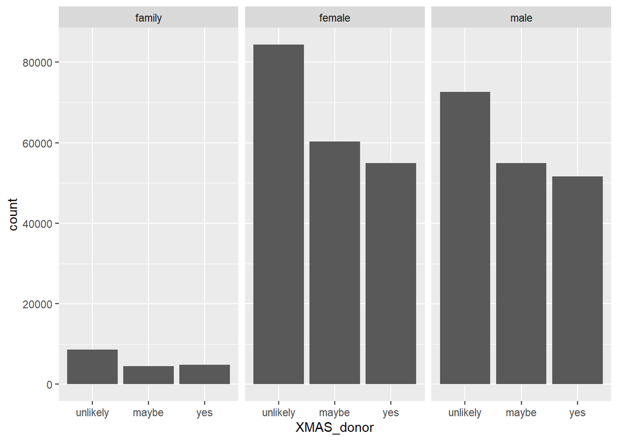

```r
ggplot(customer_segmentation_first_prepro, aes(XMAS_donor)) +
  geom_bar() +
  facet_wrap(~Gender)
```

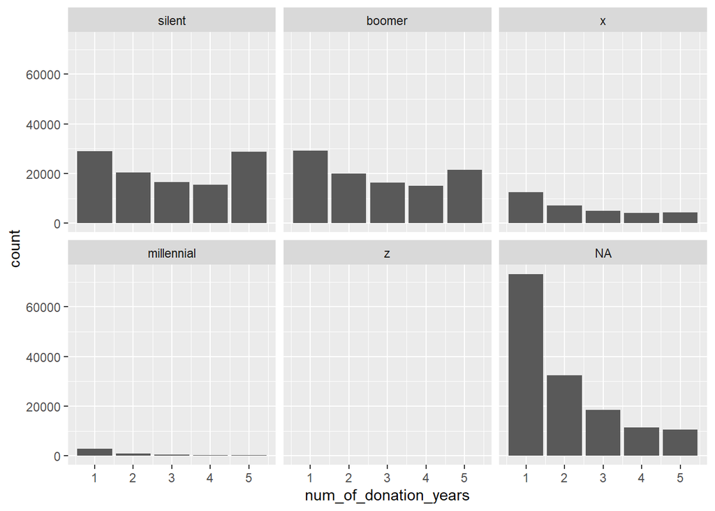

```r
ggplot(customer_segmentation_first_prepro, aes(num_of_donation_years)) +
  geom_bar() +
  facet_wrap(~generation_moniker)
```

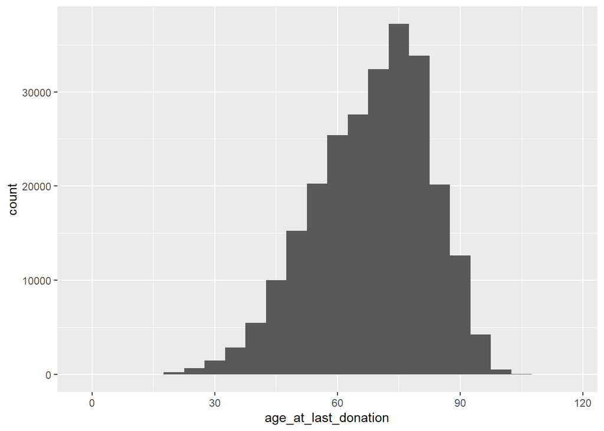

```r
ggplot(customer_segmentation_first_prepro %>% drop_na(age_at_last_donation), aes(age_at_last_donation)) +
  geom_histogram(binwidth = 5)
```

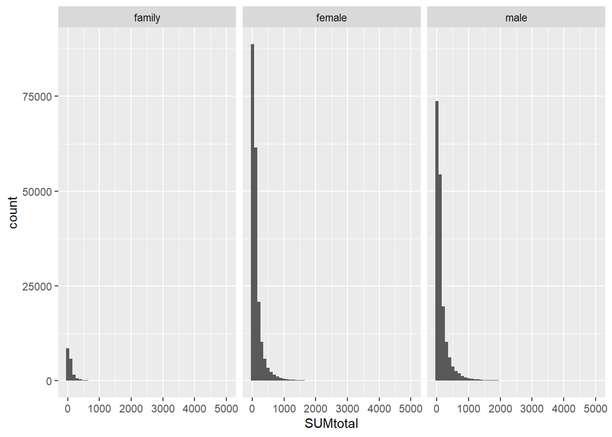

```r
ggplot(customer_segmentation_first_prepro %>% filter(SUMtotal > 0 & SUMtotal < 5000), aes(x = SUMtotal)) +
  geom_histogram(binwidth = 100) +
  facet_wrap(~Gender)
```

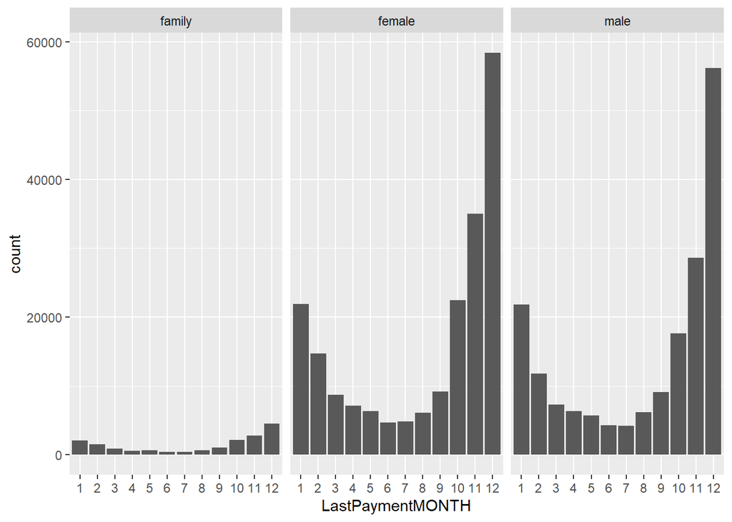

```r
ggplot(customer_segmentation_first_prepro, aes(LastPaymentMONTH)) +
  geom_bar() +
  facet_wrap(~Gender)
```

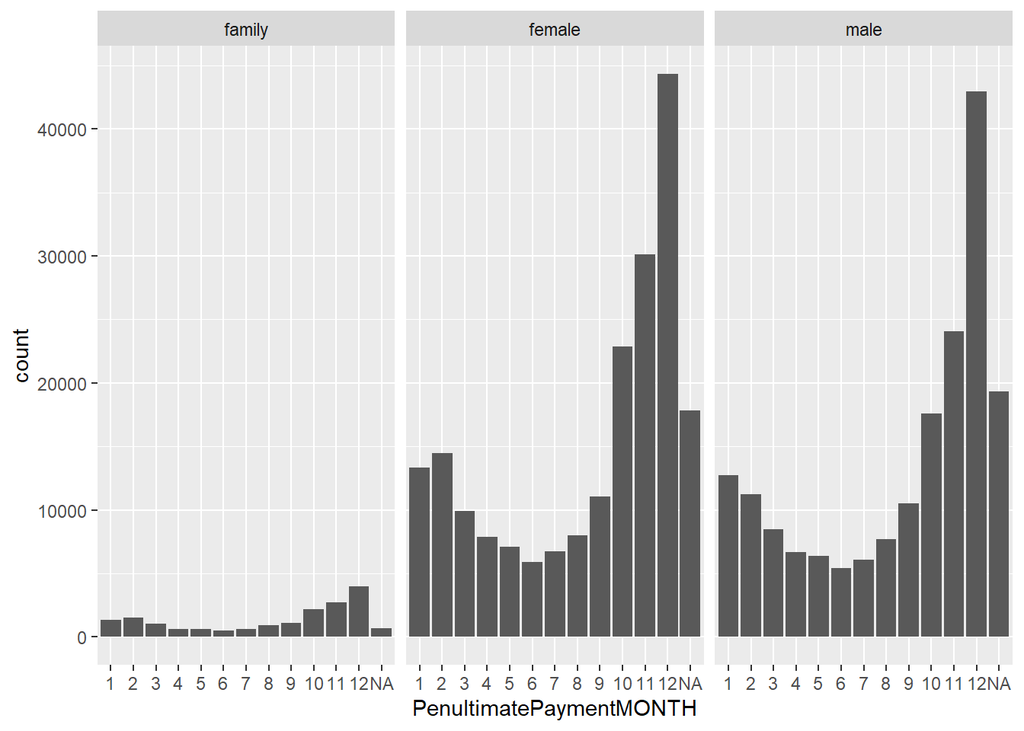

```r
ggplot(customer_segmentation_first_prepro, aes(PenultimatePaymentMONTH)) +
  geom_bar() +
  facet_wrap(~Gender)
```

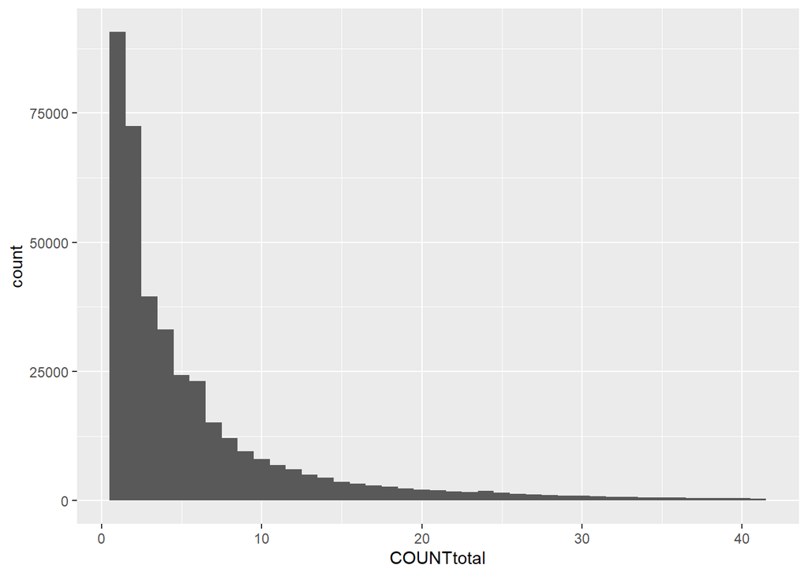

```r
ggplot(customer_segmentation_first_prepro %>% filter(COUNTtotal < (7 * 6)), aes(COUNTtotal)) +
  geom_histogram(binwidth = 1)
```

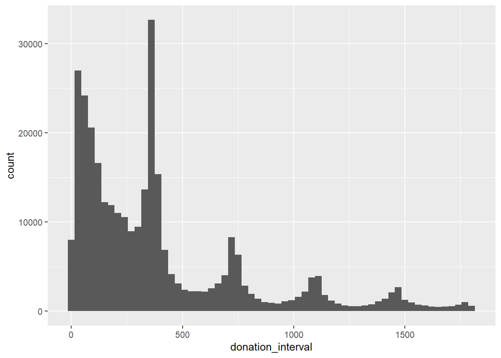

```r
ggplot(customer_segmentation_first_prepro %>% drop_na(donation_interval) %>% filter(donation_interval < (360 * 5)), aes(donation_interval)) +
  geom_histogram(binwidth = 30)
```

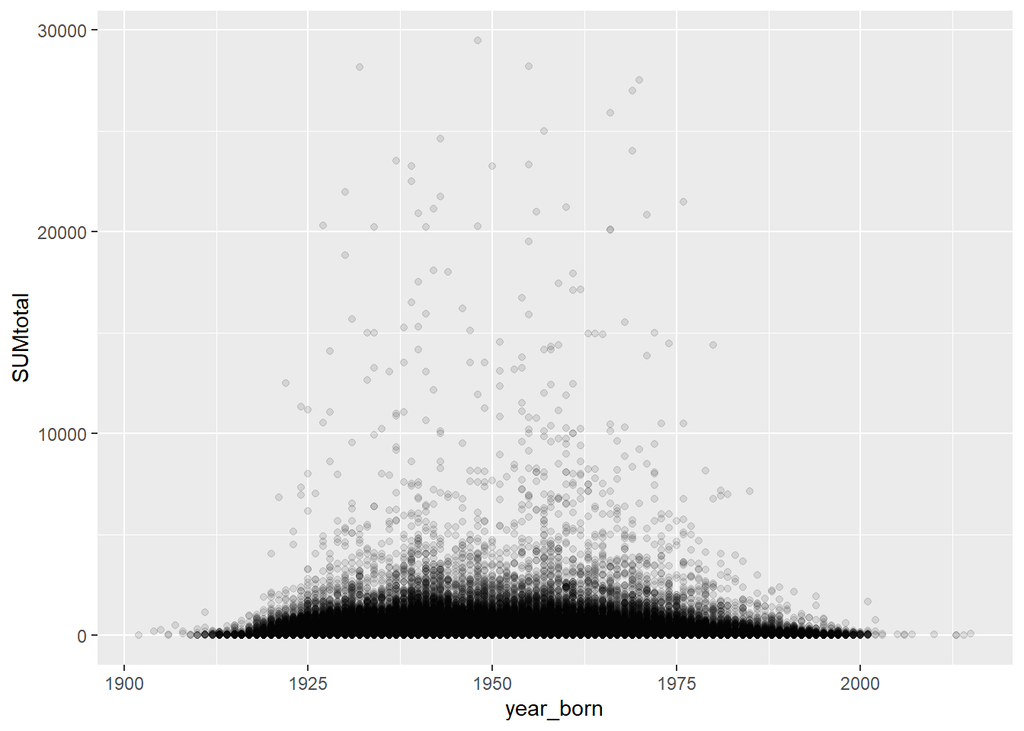

```r
mean_total_sum <- customer_segmentation_first_prepro$SUMtotal %>% mean(na.rm = TRUE)
sd_total_sum <- customer_segmentation_first_prepro$SUMtotal %>% sd(na.rm = TRUE)

ggplot(customer_segmentation_first_prepro %>% drop_na(year_born) %>% filter(SUMtotal < (mean_total_sum + sd_total_sum * 6)), aes(year_born, SUMtotal)) +
  geom_point(alpha = 1 / 10)
```

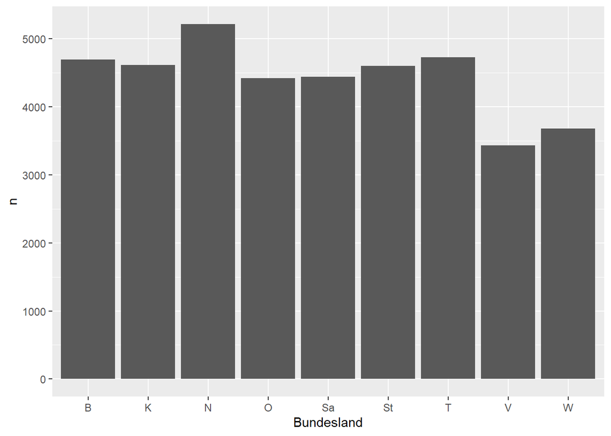

```r
# taken from https://de.statista.com/statistik/daten/studie/75396/umfrage/entwicklung-der-bevoelkerung-in-oesterreich-nach-bundesland-seit-1996/
pop_vienna <- 1921153
pop_lower_austria <- 1691040
pop_upper_austria <- 1495756
pop_styria <- 1247159
pop_tyrol <- 760161
pop_carithia <- 562230
pop_salzburg <- 560643
pop_vorarlberg <- 399164
pop_burgenland <- 296040

donors_per_state_per_100_000_inhabitants <- customer_segmentation_first_prepro %>%
  select(Bundesland) %>%
  group_by(Bundesland) %>%
  count() %>%
  ungroup() %>%
  mutate(
    n = case_when(
      Bundesland == "B" ~ n / pop_burgenland * 100000,
      Bundesland == "K" ~ n / pop_carithia * 100000,
      Bundesland == "N" ~ n / pop_lower_austria * 100000,
      Bundesland == "O" ~ n / pop_upper_austria * 100000,
      Bundesland == "Sa" ~ n / pop_salzburg * 100000,
      Bundesland == "St" ~ n / pop_styria * 100000,
      Bundesland == "T" ~ n / pop_tyrol * 100000,
      Bundesland == "V" ~ n / pop_vorarlberg * 100000,
      Bundesland == "W" ~ n / pop_vienna * 100000
    )
  )

ggplot(donors_per_state_per_100_000_inhabitants, aes(Bundesland, n)) +
  geom_col()
```

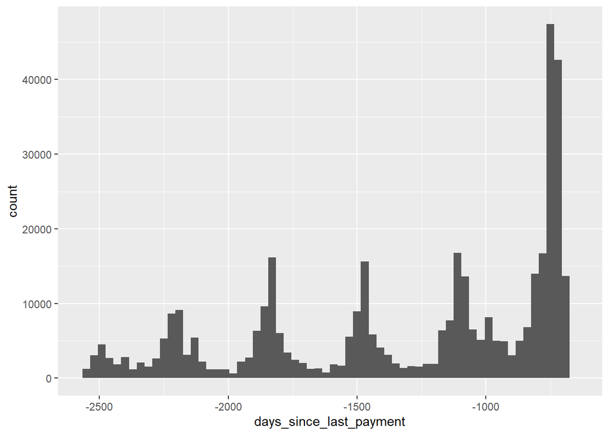

```r
ggplot(customer_segmentation_first_prepro, aes(days_since_last_payment)) +
  geom_histogram(binwidth = 30)
```

### RFM

RFM segments customers according to three variabless: Recency, Frequency, Monetary Value. Using the `rfm` package, RFM scores can be computed either on raw transaction data (one row per transaction), or on aggregated customer data (one row per customer). For the former, the method `rfm_table_order` can be used, for the latter either `rfm_table_customer` or `rfm_table_customer2`. Since our dataset represents aggregated customer data, the latter should be used. It can be computed directly from the raw data upon adding the two variables `SUMtotal` and `COUNTtotal`:

```r
library(rfm)

rfm_scores <- customer_segmentation_raw %>%
  # create new variables: total donation sum; total number of donations
  mutate(SUMtotal = SUM2015 + SUM2016 + SUM2017 + SUM2018 + SUM2019,
         COUNTtotal = COUNT2015 + COUNT2016 + COUNT2017 + COUNT2018 + COUNT2019,
         LastPaymentDate = as.Date(LastPaymentDate)) %>%
  # compute RFM scores
  rfm_table_customer_2(customer_id = ID,
                       n_transactions = COUNTtotal,
                       latest_visit_date = LastPaymentDate,
                       total_revenue = SUMtotal,
                       analysis_date = reference_date)
rfm_scores
```

| rfm | analysis_date | frequency_bins | recency_bins | monetary_bins | threshold |
| --- | --- | --- | --- | --- | --- |

```r
rfm_scores_on_prepro <- customer_segmentation_first_prepro %>%
  rfm_table_customer_2(customer_id = ID,
                       n_transactions = COUNTtotal,
                       latest_visit_date = as.Date(LastPaymentDate),
                       total_revenue = SUMtotal,
                       analysis_date = reference_date)



rfm_results_on_prepro <- rfm_scores_on_prepro$rfm %>% as.data.frame()

first_prepro_with_rfm_results <- merge(x = customer_segmentation_first_prepro,
           y = rfm_results_on_prepro,
           by.x = "ID",
           by.y = "customer_id")

first_prepro_with_rfm_results
```

| ID | Gender | Postcode | COUNT2015 | SUM2015 | MERCHANDISE2015 | COUNT2016 | SUM2016 | MERCHANDISE2016 | COUNT2017 | SUM2017 | COUNT2018 | SUM2018 | COUNT2019 | SUM2019 | MERCHANDISE2019 | LastPaymentDate | MERCHANDISE2017 | MERCHANDISE2018 | Ort | Bundesland | year_born | age_at_last_donation | generation_moniker | COUNTtotal | SUMtotal | SUMaverage | LastPaymentMONTH | PenultimatePaymentMONTH | LastPaymentYEAR | … |
| --- | --- | --- | --- | --- | --- | --- | --- | --- | --- | --- | --- | --- | --- | --- | --- | --- | --- | --- | --- | --- | --- | --- | --- | --- | --- | --- | --- | --- | --- | --- |
| 2073 | female | 1000 | 2 | 45.000 | 0 | 0 | 0.00 | 0 | 0 | 0.00 | 0 | 0.000 | 0 | 0.000 | 0 | 2015-05-05 | 0 | 0 | Wien | W | NA | NA | NA | 2 | 45.000 | 22.500000 | 5 | NA | 2015 | … |
| 2074 | female | 1010 | 0 | 0.000 | 0 | 0 | 0.00 | 0 | 0 | 0.00 | 0 | 0.000 | 1 | 15.000 | 0 | 2019-11-13 | 0 | 0 | Wien | W | NA | NA | NA | 1 | 15.000 | 15.000000 | 11 | 10 | 2019 | … |
| 2077 | female | 1010 | 0 | 0.000 | 0 | 0 | 0.00 | 0 | 0 | 0.00 | 0 | 0.000 | 1 | 15.000 | 0 | 2019-11-16 | 0 | 0 | Wien | W | NA | NA | NA | 1 | 15.000 | 15.000000 | 11 | NA | 2019 | … |
| 2079 | female | 1010 | 0 | 0.000 | 0 | 0 | 0.00 | 0 | 0 | 0.00 | 0 | 0.000 | 1 | 15.000 | 0 | 2019-12-05 | 0 | 0 | Wien | W | NA | NA | NA | 1 | 15.000 | 15.000000 | 12 | 10 | 2019 | … |
| 2080 | female | 1010 | 0 | 0.000 | 0 | 0 | 0.00 | 0 | 0 | 0.00 | 0 | 0.000 | 1 | 22.500 | 0 | 2019-11-19 | 0 | 0 | Wien | W | NA | NA | NA | 1 | 22.500 | 22.500000 | 11 | NA | 2019 | … |
| 2082 | female | 1010 | 0 | 0.000 | 0 | 0 | 0.00 | 0 | 0 | 0.00 | 0 | 0.000 | 1 | 30.000 | 0 | 2019-10-02 | 0 | 0 | Wien | W | NA | NA | NA | 1 | 30.000 | 30.000000 | 10 | 12 | 2019 | … |
| 2084 | female | 1010 | 0 | 0.000 | 0 | 0 | 0.00 | 0 | 0 | 0.00 | 0 | 0.000 | 1 | 30.000 | 0 | 2019-12-11 | 0 | 0 | Wien | W | NA | NA | NA | 1 | 30.000 | 30.000000 | 12 | NA | 2019 | … |
| 2089 | female | 1010 | 0 | 0.000 | 0 | 0 | 0.00 | 0 | 0 | 0.00 | 0 | 0.000 | 1 | 45.000 | 0 | 2019-12-11 | 0 | 0 | Wien | W | NA | NA | NA | 1 | 45.000 | 45.000000 | 12 | NA | 2019 | … |
| 2094 | female | 1010 | 0 | 0.000 | 0 | 0 | 0.00 | 0 | 0 | 0.00 | 0 | 0.000 | 3 | 45.000 | 0 | 2020-01-03 | 0 | 0 | Wien | W | NA | NA | NA | 3 | 45.000 | 15.000000 | 1 | 12 | 2020 | … |
| 2096 | female | 1010 | 0 | 0.000 | 0 | 0 | 0.00 | 0 | 0 | 0.00 | 1 | 3.750 | 0 | 0.000 | 0 | 2018-12-05 | 0 | 0 | Wien | W | NA | NA | NA | 1 | 3.750 | 3.750000 | 12 | NA | 2018 | … |

[output cut: 990 more lines]

Visual inspection of RFM scores:

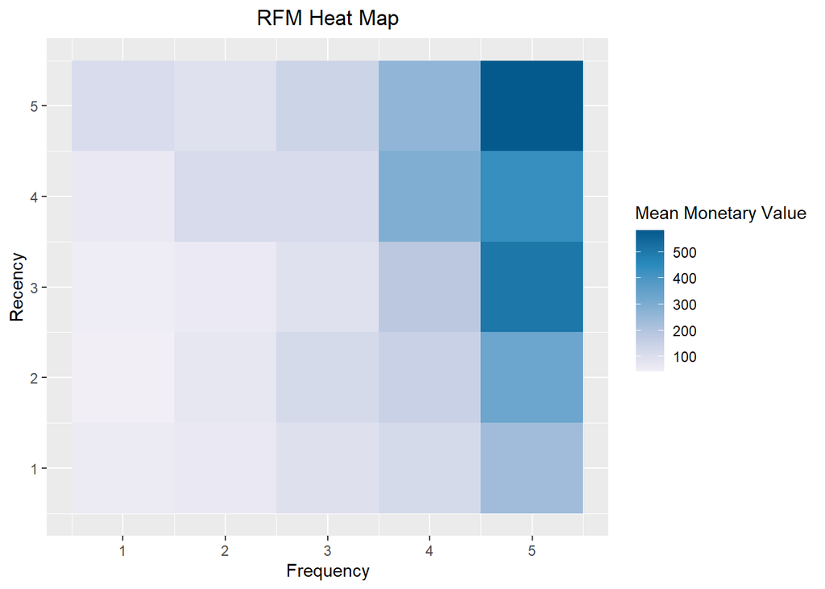

```r
rfm_heatmap(rfm_scores)
```

In the above heatmap, we can see some interesting patterns (**Note:** The higher the recency score, the more recent the last donation):

- Higher monetary values are characterized by higher donation frequencies and more recent donations. There is an obvious cluster of low monetary value for frequency values in [1,2] and recency in [1,3]. These might be **lost donors**, i.e. customers who donated only a few times, who have not donated in a while and are thus unlikely do donate again in the future.
- In the upper left corner, we see very recent customers with low frequency (i.e. new donors) who donated sums above average for this recency score. It might be worth focusing on them, since they recently demonstrated above-average donation willingness. This segment may be called **prospects**.
- In the upper right corner, we can identify frequent and recent donors who donated high sums - these are our **donation champions**.
- At the lower right (frequency in [5,5], recency in [1,3]) we see donors who frequently donated high sums in the past, but who have not been active recently. Their past donation behaviour indicates high donation willingness, so we should try to reactive them as donors, because we **do not want to loose** them. However, prior to contacting them, we should check whether these donors are still alive, because in the EDA we have seen that there are some very old donors, who might have passed away in the meantime, which would explain the lack of recent donation activity.

There are further, less obvious customer segments in the heatmap. For the sake of clarity, rather than verbally describing the segments, below we visually represent the customer segments we believe to have identified in the heatmap:

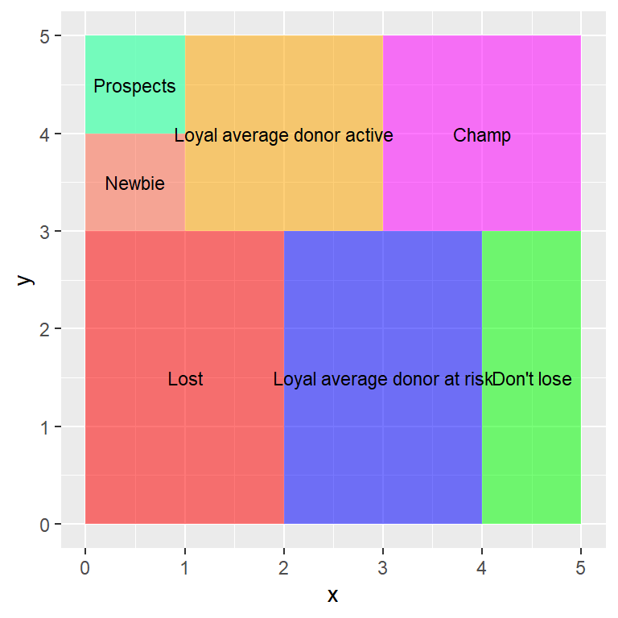

```r
# define data frame with frequency and recency score thresholds for each segment
heatmap_segments_df <- data.frame(x = c(1, 3, 4.5, 0.5, 0.5, 2, 4),
                                  y = c(1.5, 1.5, 1.5, 3.5, 4.5, 4, 4),
                                  lab = c("Lost", "Loyal average donor at risk", "Don't lose",
                                          "Newbie", "Prospects", "Loyal average donor active",
                                          "Champ"))

# plot the customer segments
ggplot(heatmap_segments_df, aes(x, y, label = lab)) +
  geom_rect(aes(xmin = 0, xmax = 2, ymin = 0, ymax = 3), fill = "red", alpha = 0.1) +
  geom_rect(aes(xmin = 2, xmax = 4, ymin = 0, ymax = 3), fill = "blue", alpha = 0.1) +
  geom_rect(aes(xmin = 4, xmax = 5, ymin = 0, ymax = 3), fill = "green", alpha = 0.1) +
  geom_rect(aes(xmin = 0, xmax = 1, ymin = 3, ymax = 4), fill = "tomato", alpha = 0.1) +
  geom_rect(aes(xmin = 0, xmax = 1, ymin = 4, ymax = 5), fill = "yellow", alpha = 0.1) +
  geom_rect(aes(xmin = 1, xmax = 3, ymin = 3, ymax = 5), fill = "orange", alpha = 0.1) +
  geom_rect(aes(xmin = 0, xmax = 1, ymin = 4, ymax = 5), fill = "cyan", alpha = 0.1) +
  geom_rect(aes(xmin = 3, xmax = 5, ymin = 3, ymax = 5), fill = "magenta", alpha = 0.1) +
  geom_text(size=3)
```

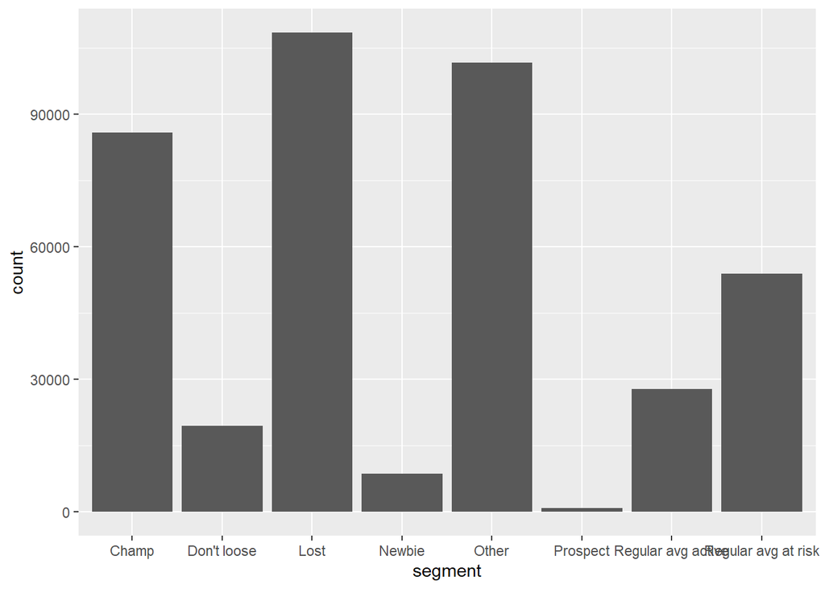

```r
rfm_segments <- rfm_scores$rfm %>%
  mutate(segment = ifelse(recency_score %in% 4:5 & frequency_score %in% 4:5 & monetary_score %in% 4:5,
                          "Champ",
                          ifelse(recency_score %in% 4:5 & frequency_score %in% 2:3 & monetary_score %in% 1:3,
                          "Regular avg active",
                          ifelse(recency_score %in% 5:5 & frequency_score %in% 1:1 & monetary_score %in% 4:5,
                          "Prospect",
                          ifelse(recency_score %in% 4:4 & frequency_score %in% 1:1 & monetary_score %in% 1:3,
                          "Newbie",
                          ifelse(recency_score %in% 1:3 & frequency_score %in% 5:5 & monetary_score %in% 4:5,
                          "Don't loose",
                          ifelse(recency_score %in% 1:3 & frequency_score %in% 3:4 & monetary_score %in% 3:4,
                          "Regular avg at risk",
                          ifelse(recency_score %in% 1:3 & frequency_score %in% 1:2 & monetary_score %in% 1:2,
                          "Lost", "Other"))))))))


rfm_segments %>% ggplot(aes(segment)) +
  geom_bar()
```

```r
rfm_segments$segment %>% table() %>% prop.table() %>% round(3) %>% sort(decreasing = T)
```

```
## .
##                Lost               Other               Champ Regular avg at risk  Regular avg active
##               0.267               0.250               0.211               0.133               0.068
##         Don't loose              Newbie            Prospect
##               0.048               0.021               0.002
```

```r
other_peeps <- rfm_segments %>% filter(segment == "Other") %>% select(customer_id) %>% unique() %>% list()

first_prepro_with_rfm_results %>% filter(ID %in% other_peeps)
```

| ID | Gender | Postcode | COUNT2015 | SUM2015 | MERCHANDISE2015 | COUNT2016 | SUM2016 | MERCHANDISE2016 | COUNT2017 | SUM2017 | COUNT2018 | SUM2018 | COUNT2019 | SUM2019 | MERCHANDISE2019 | LastPaymentDate | MERCHANDISE2017 | MERCHANDISE2018 | Ort | Bundesland | year_born | age_at_last_donation | generation_moniker | COUNTtotal | SUMtotal | SUMaverage | LastPaymentMONTH | PenultimatePaymentMONTH | LastPaymentYEAR | … |
| --- | --- | --- | --- | --- | --- | --- | --- | --- | --- | --- | --- | --- | --- | --- | --- | --- | --- | --- | --- | --- | --- | --- | --- | --- | --- | --- | --- | --- | --- | --- |

```r
# these are the same categories as above, just using the first_prepro data instead of the raw data
first_prepro_with_rfm_segments <- first_prepro_with_rfm_results %>%
  mutate(segment = ifelse(recency_score %in% 4:5 & frequency_score %in% 4:5 & monetary_score %in% 4:5,
                          "Champ",
                          ifelse(recency_score %in% 4:5 & frequency_score %in% 2:3 & monetary_score %in% 1:3,
                          "Regular avg active",
                          ifelse(recency_score %in% 5:5 & frequency_score %in% 1:1 & monetary_score %in% 4:5,
                          "Prospect",
                          ifelse(recency_score %in% 4:4 & frequency_score %in% 1:1 & monetary_score %in% 1:3,
                          "Newbie",
                          ifelse(recency_score %in% 1:3 & frequency_score %in% 5:5 & monetary_score %in% 4:5,
                          "Don't loose",
                          ifelse(recency_score %in% 1:3 & frequency_score %in% 3:4 & monetary_score %in% 3:4,
                          "Regular avg at risk",
                          ifelse(recency_score %in% 1:3 & frequency_score %in% 1:2 & monetary_score %in% 1:2,
                          "Lost", "Other"))))))))
```

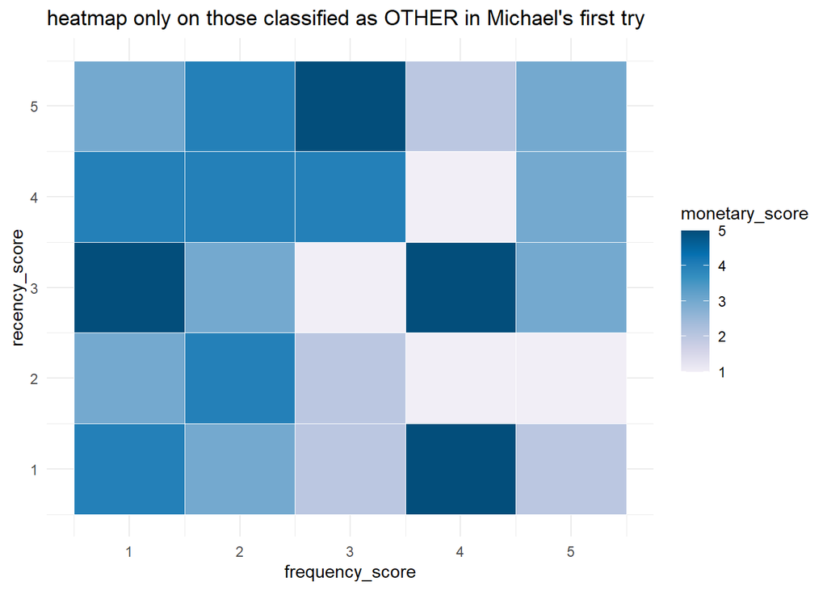

```r
first_prepro_with_rfm_segments %>% filter(segment == "Other") %>%
  ggplot(aes(frequency_score, recency_score)) +
  geom_tile(aes(fill = monetary_score), colour = "white") +
  scale_fill_distiller(palette = "PuBu", direction = +1)+
  labs(title="heatmap only on those classified as OTHER in Michael's first try")+
  theme_minimal()
```

The above heatmap shows that we e.g. missed a lot of “big donors” in the first attempt.

To remedy the faulty segmentation shown above, we resort to the customer segments (and the respective RFM score thresholds) presented in class (see slide deck of first class, p. 82 as well as https://rpubs.com/Eddie_Zaldivar/705462). We use this mainstream segmentation as our baseline:

```r
# define name of each segment
segment_names_baseline <- c("Champions", "Loyal Customers", "Potential Loyalist",
  "New Customers", "Promising", "Need Attention", "About To Sleep",
  "At Risk", "Can't Lose Them", "Lost")

# set the upper and lower bounds for recency, frequency, and monetary for each segment
recency_lower <- c(4, 2, 3, 4, 3, 2, 2, 1, 1, 1)
recency_upper <- c(5, 5, 5, 5, 4, 3, 3, 2, 1, 2)
frequency_lower <- c(4, 3, 1, 1, 1, 2, 1, 2, 4, 1)
frequency_upper <- c(5, 5, 3, 1, 1, 3, 2, 5, 5, 2)
monetary_lower <- c(4, 3, 1, 1, 1, 2, 1, 2, 4, 1)
monetary_upper <- c(5, 5, 3, 1, 1, 3, 2, 5, 5, 2)

# assign segment to each customer
rfm_segments_baseline <- rfm_segment(rfm_scores,
                                     segment_names_baseline,
                                     recency_lower,
                                     recency_upper,
                                     frequency_lower,
                                     frequency_upper,
                                     monetary_lower,
                                     monetary_upper)

rfm_segments_baseline$segment %>% table()
```

```
## .
##     About To Sleep            At Risk          Champions               Lost    Loyal Customers
##              32507              43579              85860              34688              97928
##     Need Attention             Others Potential Loyalist
##              11113              25666              75393
```

```r
# inspect segment assignment
head(rfm_segments_baseline)
```

| customer_id | segment | rfm_score | transaction_count | recency_days | amount | recency_score | frequency_score | monetary_score |
| --- | --- | --- | --- | --- | --- | --- | --- | --- |
| 1 | Potential Loyalist | 511 | 1 | 730 | 4.50 | 5 | 1 | 1 |
| 2 | Potential Loyalist | 511 | 1 | 720 | 1.53 | 5 | 1 | 1 |
| 3 | Potential Loyalist | 511 | 1 | 743 | 3.00 | 5 | 1 | 1 |
| 4 | Potential Loyalist | 411 | 1 | 927 | 4.50 | 4 | 1 | 1 |
| 5 | Potential Loyalist | 311 | 1 | 993 | 4.95 | 3 | 1 | 1 |
| 6 | Potential Loyalist | 311 | 1 | 1056 | 6.00 | 3 | 1 | 1 |

```r
# NOW ON PREPRO DATA and using numeric customer_id

# assign segment to each customer
rfm_segments_baseline_on_prepro <- rfm_segment(rfm_scores_on_prepro,
                                     segment_names_baseline,
                                     recency_lower,
                                     recency_upper,
                                     frequency_lower,
                                     frequency_upper,
                                     monetary_lower,
                                     monetary_upper)

rfm_segments_baseline_on_prepro
```

| customer_id | segment | rfm_score | transaction_count | recency_days | amount | recency_score | frequency_score | monetary_score |
| --- | --- | --- | --- | --- | --- | --- | --- | --- |
| 2073 | At Risk | 122 | 2 | 2418 | 45.000 | 1 | 2 | 2 |
| 2074 | Potential Loyalist | 411 | 1 | 765 | 15.000 | 4 | 1 | 1 |
| 2077 | Potential Loyalist | 411 | 1 | 762 | 15.000 | 4 | 1 | 1 |
| 2079 | Potential Loyalist | 511 | 1 | 743 | 15.000 | 5 | 1 | 1 |
| 2080 | Potential Loyalist | 411 | 1 | 759 | 22.500 | 4 | 1 | 1 |
| 2082 | Potential Loyalist | 412 | 1 | 807 | 30.000 | 4 | 1 | 2 |
| 2084 | Potential Loyalist | 512 | 1 | 737 | 30.000 | 5 | 1 | 2 |
| 2089 | Potential Loyalist | 512 | 1 | 737 | 45.000 | 5 | 1 | 2 |
| 2094 | Potential Loyalist | 532 | 3 | 714 | 45.000 | 5 | 3 | 2 |
| 2096 | Potential Loyalist | 311 | 1 | 1108 | 3.750 | 3 | 1 | 1 |

[output cut: 990 more lines]

```r
customer_segmentation_first_prepro
```

| ID | Gender | Postcode | COUNT2015 | SUM2015 | MERCHANDISE2015 | COUNT2016 | SUM2016 | MERCHANDISE2016 | COUNT2017 | SUM2017 | COUNT2018 | SUM2018 | COUNT2019 | SUM2019 | MERCHANDISE2019 | LastPaymentDate | MERCHANDISE2017 | MERCHANDISE2018 | Ort | Bundesland | year_born | age_at_last_donation | generation_moniker | COUNTtotal | SUMtotal | SUMaverage | LastPaymentMONTH | PenultimatePaymentMONTH | LastPaymentYEAR | … |
| --- | --- | --- | --- | --- | --- | --- | --- | --- | --- | --- | --- | --- | --- | --- | --- | --- | --- | --- | --- | --- | --- | --- | --- | --- | --- | --- | --- | --- | --- | --- |
| 2073 | female | 1000 | 2 | 45.000 | 0 | 0 | 0.00 | 0 | 0 | 0.00 | 0 | 0.000 | 0 | 0.000 | 0 | 2015-05-05 | 0 | 0 | Wien | W | NA | NA | NA | 2 | 45.000 | 22.500000 | 5 | NA | 2015 | … |
| 2074 | female | 1010 | 0 | 0.000 | 0 | 0 | 0.00 | 0 | 0 | 0.00 | 0 | 0.000 | 1 | 15.000 | 0 | 2019-11-13 | 0 | 0 | Wien | W | NA | NA | NA | 1 | 15.000 | 15.000000 | 11 | 10 | 2019 | … |
| 2077 | female | 1010 | 0 | 0.000 | 0 | 0 | 0.00 | 0 | 0 | 0.00 | 0 | 0.000 | 1 | 15.000 | 0 | 2019-11-16 | 0 | 0 | Wien | W | NA | NA | NA | 1 | 15.000 | 15.000000 | 11 | NA | 2019 | … |
| 2079 | female | 1010 | 0 | 0.000 | 0 | 0 | 0.00 | 0 | 0 | 0.00 | 0 | 0.000 | 1 | 15.000 | 0 | 2019-12-05 | 0 | 0 | Wien | W | NA | NA | NA | 1 | 15.000 | 15.000000 | 12 | 10 | 2019 | … |
| 2080 | female | 1010 | 0 | 0.000 | 0 | 0 | 0.00 | 0 | 0 | 0.00 | 0 | 0.000 | 1 | 22.500 | 0 | 2019-11-19 | 0 | 0 | Wien | W | NA | NA | NA | 1 | 22.500 | 22.500000 | 11 | NA | 2019 | … |
| 2082 | female | 1010 | 0 | 0.000 | 0 | 0 | 0.00 | 0 | 0 | 0.00 | 0 | 0.000 | 1 | 30.000 | 0 | 2019-10-02 | 0 | 0 | Wien | W | NA | NA | NA | 1 | 30.000 | 30.000000 | 10 | 12 | 2019 | … |
| 2084 | female | 1010 | 0 | 0.000 | 0 | 0 | 0.00 | 0 | 0 | 0.00 | 0 | 0.000 | 1 | 30.000 | 0 | 2019-12-11 | 0 | 0 | Wien | W | NA | NA | NA | 1 | 30.000 | 30.000000 | 12 | NA | 2019 | … |
| 2089 | female | 1010 | 0 | 0.000 | 0 | 0 | 0.00 | 0 | 0 | 0.00 | 0 | 0.000 | 1 | 45.000 | 0 | 2019-12-11 | 0 | 0 | Wien | W | NA | NA | NA | 1 | 45.000 | 45.000000 | 12 | NA | 2019 | … |
| 2094 | female | 1010 | 0 | 0.000 | 0 | 0 | 0.00 | 0 | 0 | 0.00 | 0 | 0.000 | 3 | 45.000 | 0 | 2020-01-03 | 0 | 0 | Wien | W | NA | NA | NA | 3 | 45.000 | 15.000000 | 1 | 12 | 2020 | … |
| 2096 | female | 1010 | 0 | 0.000 | 0 | 0 | 0.00 | 0 | 0 | 0.00 | 1 | 3.750 | 0 | 0.000 | 0 | 2018-12-05 | 0 | 0 | Wien | W | NA | NA | NA | 1 | 3.750 | 3.750000 | 12 | NA | 2018 | … |

[output cut: 990 more lines]

```r
# merge with prepro_data
rfm_results_baseline_on_prepro <- merge(x = customer_segmentation_first_prepro,
           y = rfm_segments_baseline_on_prepro,
           by.x = "ID",
           by.y = "customer_id")

# inspect segment assignment
head(rfm_results_baseline_on_prepro)
```

|  | ID | Gender | Postcode | COUNT2015 | SUM2015 | MERCHANDISE2015 | COUNT2016 | SUM2016 | MERCHANDISE2016 | COUNT2017 | SUM2017 | COUNT2018 | SUM2018 | COUNT2019 | SUM2019 | MERCHANDISE2019 | LastPaymentDate | MERCHANDISE2017 | MERCHANDISE2018 | Ort | Bundesland | year_born | age_at_last_donation | generation_moniker | COUNTtotal | SUMtotal | SUMaverage | LastPaymentMONTH | PenultimatePaymentMONTH | … |
| --- | --- | --- | --- | --- | --- | --- | --- | --- | --- | --- | --- | --- | --- | --- | --- | --- | --- | --- | --- | --- | --- | --- | --- | --- | --- | --- | --- | --- | --- | --- |
| 1 | 2073 | female | 1000 | 2 | 45 | 0 | 0 | 0 | 0 | 0 | 0 | 0 | 0 | 0 | 0.0 | 0 | 2015-05-05 | 0 | 0 | Wien | W | NA | NA | NA | 2 | 45.0 | 22.5 | 5 | NA | … |
| 2 | 2074 | female | 1010 | 0 | 0 | 0 | 0 | 0 | 0 | 0 | 0 | 0 | 0 | 1 | 15.0 | 0 | 2019-11-13 | 0 | 0 | Wien | W | NA | NA | NA | 1 | 15.0 | 15.0 | 11 | 10 | … |
| 3 | 2077 | female | 1010 | 0 | 0 | 0 | 0 | 0 | 0 | 0 | 0 | 0 | 0 | 1 | 15.0 | 0 | 2019-11-16 | 0 | 0 | Wien | W | NA | NA | NA | 1 | 15.0 | 15.0 | 11 | NA | … |
| 4 | 2079 | female | 1010 | 0 | 0 | 0 | 0 | 0 | 0 | 0 | 0 | 0 | 0 | 1 | 15.0 | 0 | 2019-12-05 | 0 | 0 | Wien | W | NA | NA | NA | 1 | 15.0 | 15.0 | 12 | 10 | … |
| 5 | 2080 | female | 1010 | 0 | 0 | 0 | 0 | 0 | 0 | 0 | 0 | 0 | 0 | 1 | 22.5 | 0 | 2019-11-19 | 0 | 0 | Wien | W | NA | NA | NA | 1 | 22.5 | 22.5 | 11 | NA | … |
| 6 | 2082 | female | 1010 | 0 | 0 | 0 | 0 | 0 | 0 | 0 | 0 | 0 | 0 | 1 | 30.0 | 0 | 2019-10-02 | 0 | 0 | Wien | W | NA | NA | NA | 1 | 30.0 | 30.0 | 10 | 12 | … |

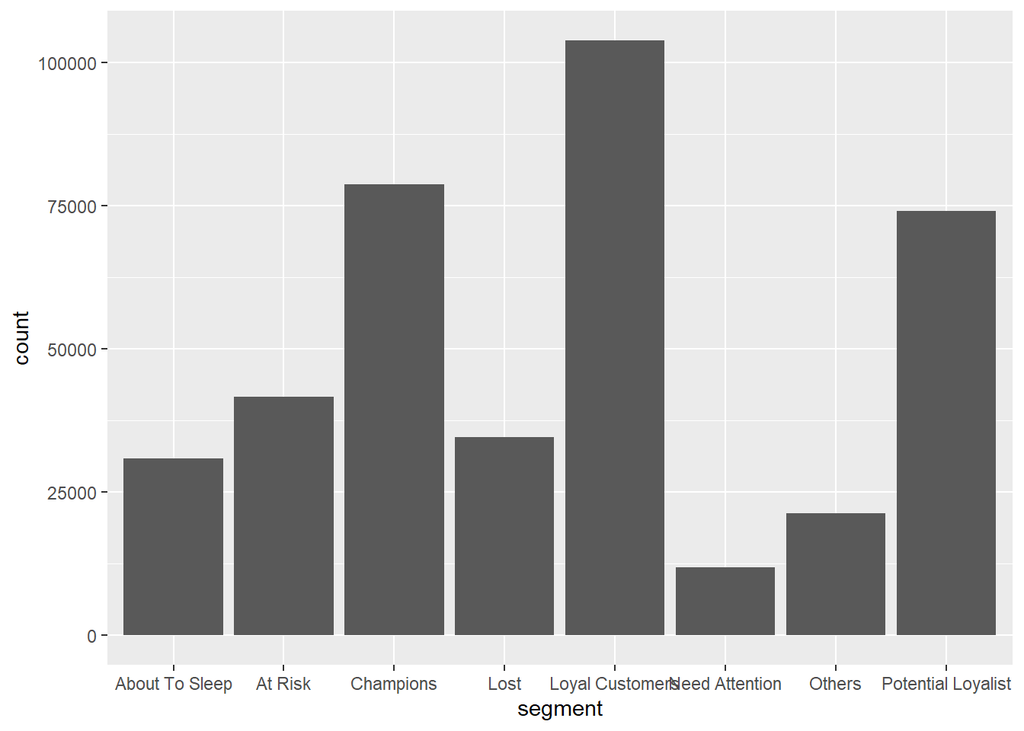

```r
rfm_results_baseline_on_prepro %>% ggplot(aes(segment)) +
  geom_bar()
```

```r
rfm_results_baseline_on_prepro$segment %>% table() %>% prop.table() %>% round(2) %>% sort(decreasing = T)
```

```
## .
##    Loyal Customers          Champions Potential Loyalist            At Risk               Lost
##               0.26               0.20               0.19               0.10               0.09
##     About To Sleep             Others     Need Attention
##               0.08               0.05               0.03
```

```r
rfm_results_baseline_on_prepro$segment %>% table() %>% prop.table() %>% round(3) %>% sort(decreasing = T)
```

```
## .
##    Loyal Customers          Champions Potential Loyalist            At Risk               Lost
##              0.262              0.198              0.187              0.105              0.087
##     About To Sleep             Others     Need Attention
##              0.078              0.054              0.030
```

Finally, we can inspect median scores for each RFM component per segment:

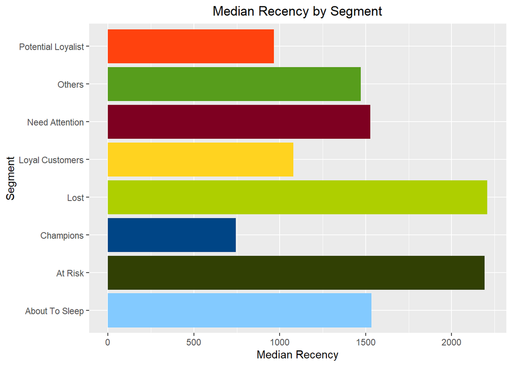

```r
rfm_plot_median_recency(rfm_results_baseline_on_prepro)
```

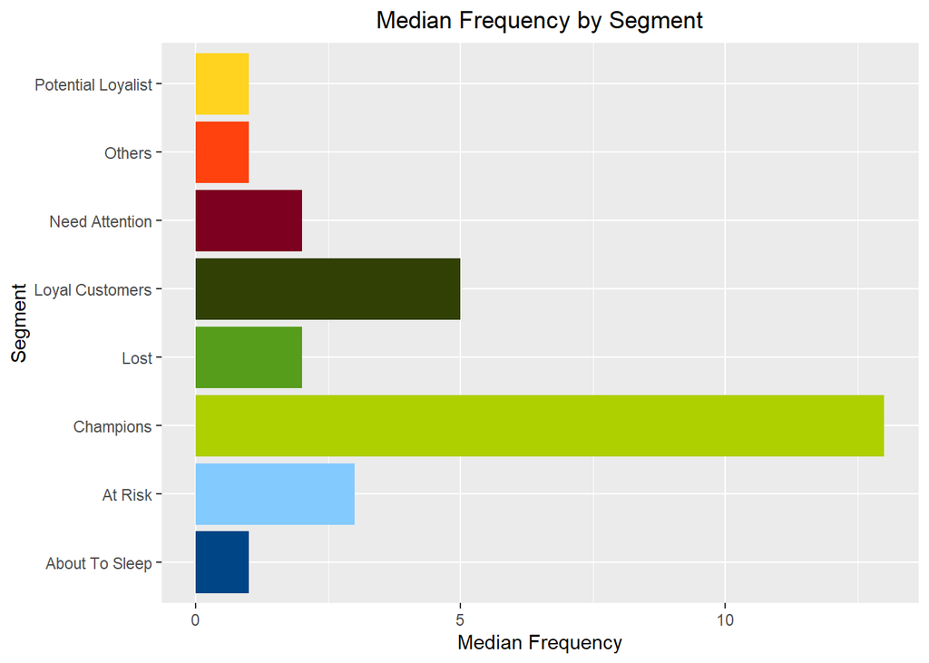

```r
rfm_plot_median_frequency(rfm_results_baseline_on_prepro)
```

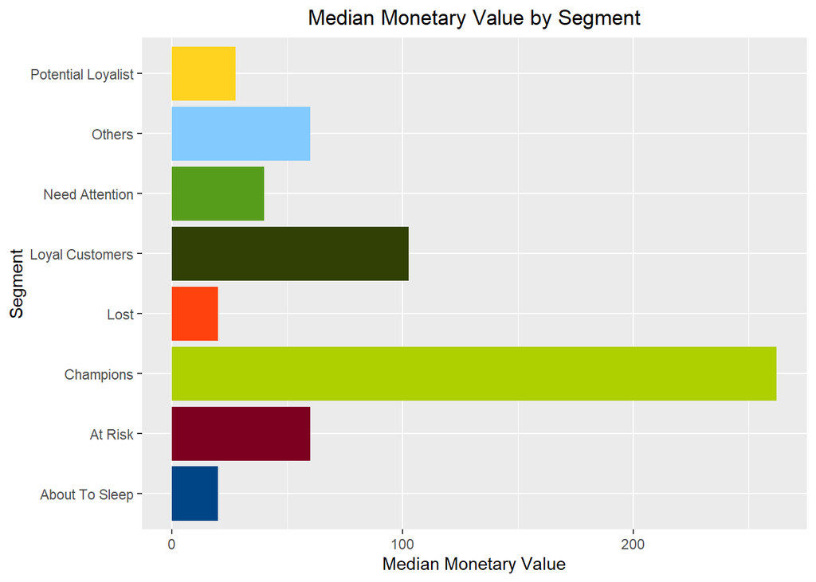

```r
rfm_plot_median_monetary(rfm_results_baseline_on_prepro)
```

#### clean-up

```r
rm(customer_segmentation_complete,
   customer_segmentation_raw,
   customer_segmentation_with_zip,
   customers_prep,
   donors_per_state_per_100_000_inhabitants,
   other_peeps,
   rfm_scores,
   rfm_scores_on_prepro,
   rfm_segments,
   rfm_segments_baseline,
   zip_code_list)
```